# Data analysis examples

UCSF Ophthalmology Residents

Ben Arnold (ben.arnold@ucsf.edu)

Run: 2021-10-19 16:25:53

# Summary

This notebook includes some analysis examples that follow an ophthalmology resident introductory lecture on data analysis.

# Preamble

Clear the workspace and load all packages and color palettes used below.

```r
#-----------------------------
# preamble
#-----------------------------
# clear memory
rm(list=ls())

# load packages
library(here)
library(tidyverse)
library(broom)
library(epitools)
library(sandwich)
library(lmtest)
library(kableExtra)
  options(knitr.table.format = "html")

# safe color blind palette
# http://jfly.iam.u-tokyo.ac.jp/color/
# http://www.cookbook-r.com/Graphs/Colors_(ggplot2)/
cbpal <- c("#999999", "#E69F00", "#56B4E9", "#009E73", "#F0E442", "#0072B2", "#D55E00", "#CC79A7")
```

# Prajna 2013

This analysis example uses primary outcome data from the MUTT study:

Prajna, N. V., Krishnan, T., Mascarenhas, J., Rajaraman, R., Prajna, L., Srinivasan, M., Raghavan, A., Oldenburg, C. E., Ray, K. J., Zegans, M. E., McLeod, S. D., Porco, T. C., Acharya, N. R., Lietman, T. M. & Mycotic Ulcer Treatment Trial Group. The mycotic ulcer treatment trial: a randomized trial comparing natamycin vs voriconazole. JAMA Ophthalmol. 131, 422–429 (2013). https://pubmed.ncbi.nlm.nih.gov/23710492/

## Load the MUTT data

The de-identified BSCVA data are stored in the GitHub repository under `/data`

```r
#-----------------------------
# read-in the MUTT I data
# format the tr variable
# as a factor, with
# Voriconazole as the reference level
#-----------------------------
d <- read_csv(here("data","mutt1.csv")) %>%
  mutate(tr = factor(tr, levels = c("Voriconazole","Natamycin")))

#-----------------------------
# pivot the data into long format
# to make it easy to plot
# the data in a single panel
#-----------------------------
dl <- d %>%
  pivot_longer(cols = c("logmar_0","logmar_3"),
               names_to = "meas", names_prefix = "logmar_",
               values_to = "logmar") %>%
  mutate(time = ifelse(meas == 0, "Baseline", "3 months"),
         time = factor(time, levels = c("Baseline","3 months")))
```

## Distributions of BSCVA

Plot the distribution of BSCVA at enrollment. The distributions look very similar, balanced by randomization.

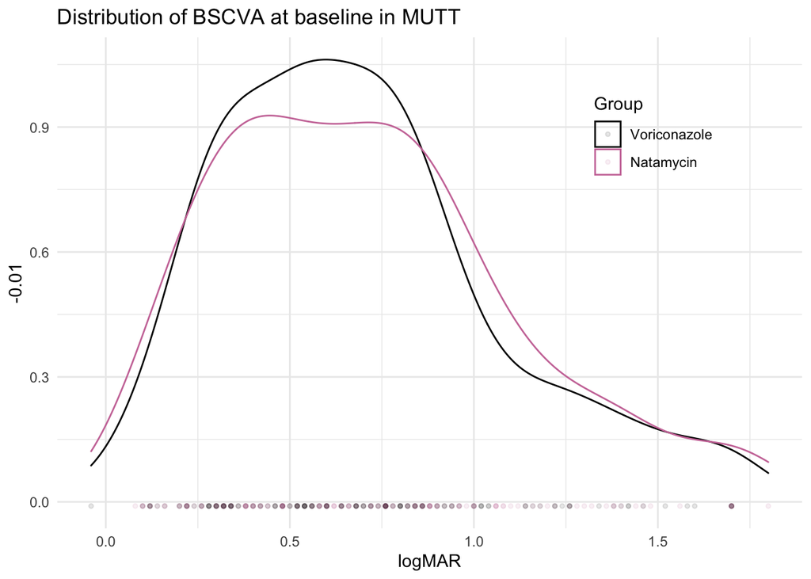

```r
# make a figure at both time points
pcols <- c("black",cbpal[c(8,4)])
plot_bscva_baseline <- ggplot(data = dl %>% filter(time=="Baseline"), aes(logmar,color=tr)) +
  geom_density() +
  # add rug plot below, with separate lines for each measure
  geom_point(data=filter(dl,time=="Baseline"),aes(x=logmar,y=-0.01),size=1,alpha=0.1) +
  labs(x="logMAR",title="Distribution of BSCVA at baseline in MUTT") +
  scale_color_manual(values=pcols,guide_colorbar(title="Group")) +
  theme_minimal() +
  theme(
    legend.position = c(0.8,0.8)
  )
plot_bscva_baseline
```

```r
# ggsave(here("output","mutt-bscva-baseline.png"),plot_bscva_baseline, device = "png", width = 5, height = 3)
```

Plot distributions of BSCVA measured in MUTT at enrollment and 3-months.

Patients who received Natamycin appear to have better vision at 3 months (lower logMAR). We can use statistical tests (next section) to formally test if the two groups differ.

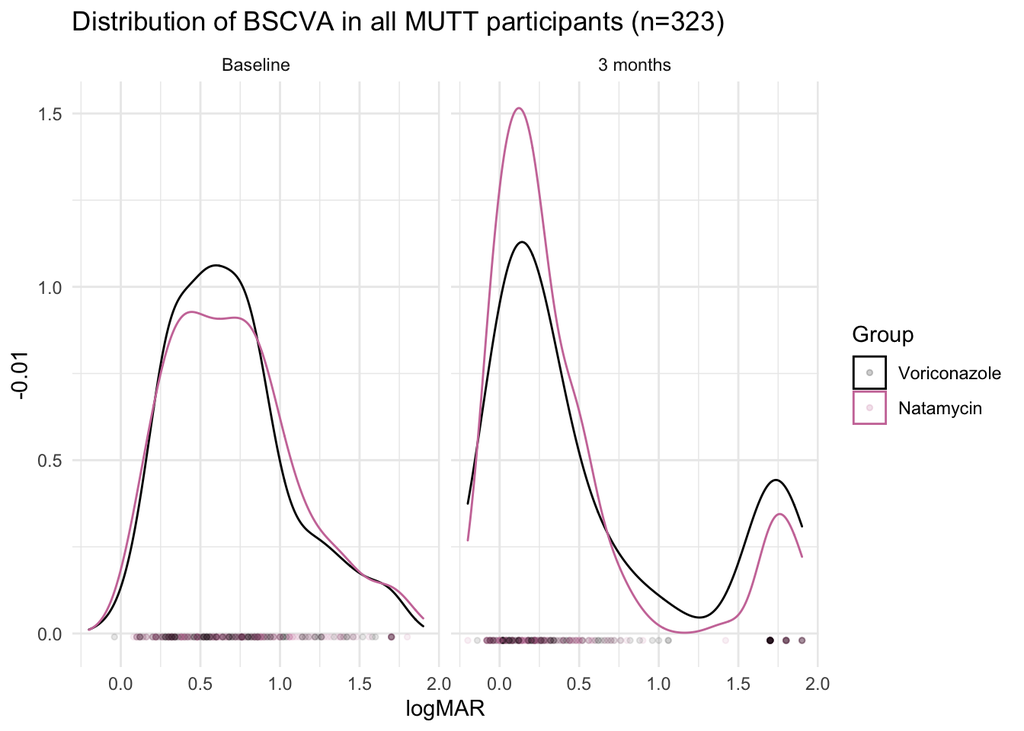

```r
# make a figure at both time points
pcols <- c("black",cbpal[c(8,4)])
plot_bscva_all <- ggplot(data = dl, aes(logmar,color=tr)) +
  facet_grid(.~time) +
  geom_density() +
  # add rug plot below, with separate lines for each measure
  geom_point(data=filter(dl,time=="Baseline"),aes(x=logmar,y=-0.01),size=1,alpha=0.1) +
  geom_point(data=filter(dl,time=="3 months"),aes(x=logmar,y=-0.02),size=1,alpha=0.1) +
  labs(x="logMAR",title="Distribution of BSCVA in all MUTT participants (n=323)") +
  scale_color_manual(values=pcols,guide_colorbar(title="Group")) +
  theme_minimal()
plot_bscva_all
```

```r
# ggsave(here("output","mutt-bscva-baseline.png"),plot_bscva_all, device = "png", width = 8, height = 3)
```

## Statistical Testing

### T-test

A simple comparison of two quantitative variables is a T-test. The results of the test suggest that logMAR is lower in the Natamycin group.

```r
t.test(logmar_3 ~ tr, data=d)
```

```
##
##  Welch Two Sample t-test
##
## data:  logmar_3 by tr
## t = 2.2004, df = 281.36, p-value = 0.02859
## alternative hypothesis: true difference in means between group Voriconazole and group Natamycin is not equal to 0
## 95 percent confidence interval:
##  0.01647853 0.29612420
## sample estimates:
## mean in group Voriconazole    mean in group Natamycin
##                  0.5628767                  0.4065753
```

### Wilcoxon Rank-Sum test

The logMAR distributions at 3 months are not normally distributed. The Wilcoxon Rank-Sum tests (also called the Mann-Whitney U test) is a non-parametric alternative that does not assume normality.

```r
wilcox.test(logmar_3 ~ tr, data=d)
```

```
##
##  Wilcoxon rank sum test with continuity correction
##
## data:  logmar_3 by tr
## W = 11825, p-value = 0.1056
## alternative hypothesis: true location shift is not equal to 0
```

## Regression

### Unadjusted regression

```r
fit <- lm(logmar_3 ~ tr, data=d)
summary(fit)
```

```
##
## Call:
## lm(formula = logmar_3 ~ tr, data = d)
##
## Residuals:
##     Min      1Q  Median      3Q     Max
## -0.7029 -0.4066 -0.2429  0.1012  1.4934
##
## Coefficients:
##             Estimate Std. Error t value Pr(>|t|)
## (Intercept)  0.56288    0.05023   11.21   <2e-16 ***
## trNatamycin -0.15630    0.07103   -2.20   0.0286 *
## ---
## Signif. codes:  0 '***' 0.001 '**' 0.01 '*' 0.05 '.' 0.1 ' ' 1
##
## Residual standard error: 0.6069 on 290 degrees of freedom
##   (31 observations deleted due to missingness)
## Multiple R-squared:  0.01642,    Adjusted R-squared:  0.01303
## F-statistic: 4.842 on 1 and 290 DF,  p-value: 0.02857
```

```r
knitr::kable(tidy(fit, conf.int = TRUE), digits = 2) %>%
  kable_styling(bootstrap_options = "striped")
```

| term | estimate | std.error | statistic | p.value | conf.low | conf.high |
| --- | --- | --- | --- | --- | --- | --- |
| (Intercept) | 0.56 | 0.05 | 11.21 | 0.00 | 0.46 | 0.66 |
| trNatamycin | -0.16 | 0.07 | -2.20 | 0.03 | -0.30 | -0.02 |

In this unadjusted model, the interpretation of the intercept is the 3 month mean BSCVA in the Voriconazole group, and the `trNatamycin` estimate is the difference in logMAR (Natamycin - Voriconazole).

### Adjusted for baseline BSCVA

```r
fit2 <- lm(logmar_3 ~ logmar_0 + tr, data=d)
summary(fit2)
```

```
##
## Call:
## lm(formula = logmar_3 ~ logmar_0 + tr, data = d)
##
## Residuals:
##     Min      1Q  Median      3Q     Max
## -1.1098 -0.3266 -0.1534  0.1321  1.8955
##
## Coefficients:
##             Estimate Std. Error t value Pr(>|t|)
## (Intercept)  0.05640    0.07329   0.769    0.442
## logmar_0     0.72553    0.08314   8.727   <2e-16 ***
## trNatamycin -0.15342    0.06330  -2.424    0.016 *
## ---
## Signif. codes:  0 '***' 0.001 '**' 0.01 '*' 0.05 '.' 0.1 ' ' 1
##
## Residual standard error: 0.5409 on 289 degrees of freedom
##   (31 observations deleted due to missingness)
## Multiple R-squared:  0.2215, Adjusted R-squared:  0.2162
## F-statistic: 41.12 on 2 and 289 DF,  p-value: < 2.2e-16
```

```r
knitr::kable(tidy(fit2, conf.int = TRUE), digits = 2) %>%
  kable_styling(bootstrap_options = "striped")
```

| term | estimate | std.error | statistic | p.value | conf.low | conf.high |
| --- | --- | --- | --- | --- | --- | --- |
| (Intercept) | 0.06 | 0.07 | 0.77 | 0.44 | -0.09 | 0.20 |
| logmar_0 | 0.73 | 0.08 | 8.73 | 0.00 | 0.56 | 0.89 |
| trNatamycin | -0.15 | 0.06 | -2.42 | 0.02 | -0.28 | -0.03 |

In the model that adjusts for each patient’s baseline logMAR, the intercept value is no longer easy to interpret (technically it is the logMAR amon Voriconazole patients with baseline logMAR = 0). The interpretation of the `logmar_0` coefficient is the increase in logMAR at 3 months associated with an increase of 1 in logMAR at baseline.

Our main focus remains on the `trNatamycin` estimate, which is the difference in logMAR between groups (Natamycin - Voriconazole), adjusting for baseline logMAR.

It is very similar to the unadjusted analysis, but is slightly more precise (smaller SE, narrower 95% CI). Compare this value to that reported in Table 5 of Prajna et al (2013).

# Weiss 2015

This analysis follows the paper:

Weiss, D. M., Casten, R. J., Leiby, B. E., Hark, L. A., Murchison, A. P., Johnson, D., Stratford, S., Henderer, J., Rovner, B. W. & Haller, J. A. Effect of Behavioral Intervention on Dilated Fundus Examination Rates in Older African American Individuals With Diabetes Mellitus: A Randomized Clinical Trial. JAMA Ophthalmol. 133, 1005–1012 (2015). https://pubmed.ncbi.nlm.nih.gov/26068230/

## Make the dataset

Since the original paper reports the patient numbers and outcome frequencies in each arm, we can re-create the dataset with a few lines of code.

```r
#-------------------------------
# create the dataset from
# results reported in Table 2
#-------------------------------
dfe1 <- c(rep(1,80),rep(0,11))
dfe0 <- c(rep(1,30),rep(0,58))
tr <- c(rep("BADRP",91), rep("ST",88))
dweiss <- data.frame(tr = tr, dfe = c(dfe1,dfe0)) %>%
  mutate(pid = row_number(),
         tr = factor(tr, levels = c("ST","BADRP"))) %>%
  select(pid,tr,dfe)
```

## Estimate the risk ratio (RR)

Here, we use the `epitab` package to estimate different measures of effect for binary outcomes.

The risk ratio is simply the proportion of patients who had dilated fundus examinations (DFEs) in the two groups: $RR = p_1 / p_0$

```r
options(knitr.kable.NA = '')

rr_est <- epitab(x=dweiss$tr, y = dweiss$dfe, method = "riskratio")

knitr::kable(rr_est$tab, digits = 2) %>%
  kable_styling(bootstrap_options = "striped")
```

|  | 0 | p0 | 1 | p1 | riskratio | lower | upper | p.value |
| --- | --- | --- | --- | --- | --- | --- | --- | --- |
| ST | 58 | 0.66 | 30 | 0.34 | 1.00 |  |  |  |
| BADRP | 11 | 0.12 | 80 | 0.88 | 2.58 | 1.91 | 3.48 | 0 |

## Estimate the odds ratio (OR)

Sometimes, studies will compare groups based on binary outcomes using the odds ratio (OR). The odds of an outcome is the probability that it will happen divided by the probability it will not happen: $p/(1-p)$, and so the OR between two groups is: $OR = \frac{p_1 / (1-p1)}{p_0 / (1-p_0)}$.

The OR will always be further from the null (1.0) compared to the RR. For rare outcomes, they are very close, but for outcomes with high prevalence (e.g., >25%) the two measures will be *very* different. In this example, the OR is:

```r
or_est <- epitab(x=dweiss$tr, y = dweiss$dfe, method = "oddsratio")

knitr::kable(or_est$tab, digits = 2) %>%
  kable_styling(bootstrap_options = "striped")
```

|  | 0 | p0 | 1 | p1 | oddsratio | lower | upper | p.value |
| --- | --- | --- | --- | --- | --- | --- | --- | --- |
| ST | 58 | 0.84 | 30 | 0.27 | 1.00 |  |  |  |
| BADRP | 11 | 0.16 | 80 | 0.73 | 14.06 | 6.52 | 30.34 | 0 |

*Much* larger than the RR. Both are technically correct, but in this case with a very common outcome the RR is arguably easier to interpret.

Why to people estimate the OR if it can be hard to interpret? One reason is that it is easy to estimate ORs using logistic regression (next section).

## Estimate the OR with regression

The logit link is the natural link for the binomial family in generalized linear models (GLMs), and so logistic regression models are a very common analysis technique for binary outcomes. To fit a logistic model in R, you can use the `glm` package. Here is an example using the Weiss et al. (2015) study:

```r
or_fit <- glm(dfe ~ tr, data= dweiss, family = binomial(link = "logit"))
knitr::kable(tidy(or_fit,conf.int = TRUE, exponentiate = TRUE), digits = 2) %>%
  kable_styling(bootstrap_options = "striped")
```

| term | estimate | std.error | statistic | p.value | conf.low | conf.high |
| --- | --- | --- | --- | --- | --- | --- |
| (Intercept) | 0.52 | 0.22 | -2.93 | 0 | 0.33 | 0.80 |
| trBADRP | 14.06 | 0.39 | 6.74 | 0 | 6.73 | 31.65 |

The estimated OR matches the value exactly from the `epitools` package (which essentially estimates it without a model).

## Estimate the RR with regression

It turns out that you can also estimate the RR using regression by changing the link function in a GLM to a log link from a logit link in a binomial model. This paper provides the details:

McNutt, L.-A., Wu, C., Xue, X. & Hafner, J. P. Estimating the relative risk in cohort studies and clinical trials of common outcomes. Am. J. Epidemiol. 157, 940–943 (2003). https://pubmed.ncbi.nlm.nih.gov/12746247/

As per above, estimating the RR can sometimes be advantageous to improve the interpretatbility of the effect estimate.

The problem is that sometimes log-binomial models fail to converge, and that will be the case for this example! When that happens, a valid alternative is to use what is called a “modified Poisson” regression approach. In this case, we specify a GLM with a Poisson outcome distribution and a log link. However, since we know that there is some model-misspecification (the model assumes the outcome is Poisson but we know it is Binomial) we need to use robust standard errors to get correct SEs and 95% confidence intervals. This paper provides the details:

Zou, G. A modified poisson regression approach to prospective studies with binary data. Am. J. Epidemiol. 159, 702–706 (2004). https://pubmed.ncbi.nlm.nih.gov/15033648/

You can estimate robust SEs in R using the `sandwich` and `lmtest` packages. This code chunk provides an example:

```r
# log-binomial regression does not converge
# rr_fit <- glm(dfe ~ tr, data= dweiss, family = binomial(link = "log"))

# so use modified poisson with robust SEs
rr_fit <- glm(dfe ~ tr, data= dweiss, family = poisson(link = "log"))
rr_fit_robust <- coeftest(rr_fit, vcov = vcovHC(rr_fit))

rr_fit_tab <- as.data.frame(rr_fit_robust[,1:4]) %>%
  mutate(lab = c("Intercept","BADRP")) %>%
  mutate(RR = exp(Estimate),
         RRlb = exp(Estimate - 1.96*`Std. Error`),
         RRub = exp(Estimate + 1.96*`Std. Error`)
         ) %>%
  filter(lab == "BADRP") %>%
  select(lab, RR, RRlb, RRub, `z value`, `Pr(>|z|)`)

knitr::kable(rr_fit_tab, digits = 2) %>%
  kable_styling(bootstrap_options = "striped")
```

|  | lab | RR | RRlb | RRub | z value | Pr(>\|z\|) |
| --- | --- | --- | --- | --- | --- | --- |
| trBADRP | BADRP | 2.58 | 1.9 | 3.49 | 6.11 | 0 |